# Titanic Dataset Inferences

Karthick Raja, Rahul Sathyajit

#### Extracting the data and Function for the Hypothesis testing

get the data from here: https://drive.google.com/file/d/1O3-thqx_6cyWQ6z7VxIsPwxfDfWTtzXZ/view?usp=sharing

```r
#reading the data into a data frame
data1<-read.csv("C:\\Users\\Lenovo\\Desktop\\stats-assignment 2\\titanic.csv") #change the path here
#Test to be used
nptest<-function(x)
{
  Chisq<-chisq.test(x)
  Fis<-fisher.test(x)
  df<-data.frame(Method=c(Chisq$method, Fis$method),
                 P.Value=c(Chisq$p.value, Fis$p.value))
  df
}

sigtest<-function(x,y)
{
  kst<-ks.test(x,y)
  wil<-wilcox.test(x,y)
  df<-data.frame(Method=c(kst$method, wil$method),
                 P.Value=c(kst$p.value, wil$p.value))
  df
}

normtest<-function(x)
{
  library(nortest)
  s<-shapiro.test(x)
  ad<-ad.test(x)
  cvm<-cvm.test(x)
  ll<-lillie.test(x)
  sf<-sf.test(x)
  df<-data.frame(Method=c(s$method, ad$method, cvm$method, ll$method, sf$method),
                 P.Value=c(s$p.value, ad$p.value, cvm$p.value, ll$p.value, sf$p.value))
  df
}
```

#### *1.Is there a significant difference in Age distribution between those who survived and those who did not?*

#### Data Analysis

```r
#having a table for age and survival
asu <- data.frame(data1$Age,data1$Survived)
#Dividing Survived and Not Survived
asu0<-subset(asu,asu$data1.Survived==0)
asu1<-subset(asu,asu$data1.Survived==1)
```

#### Plots and Graphs

###### Boxplot

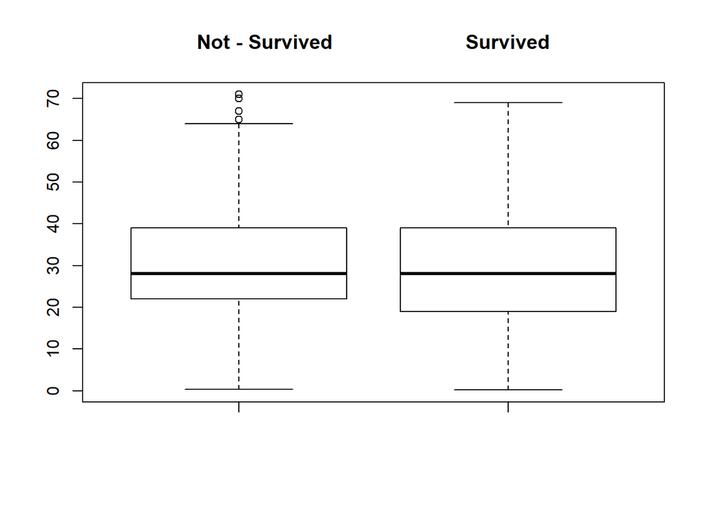

```r
boxplot(asu0$data1.Age,asu1$data1.Age,main='Not - Survived                       Survived')
```

###### Histogram

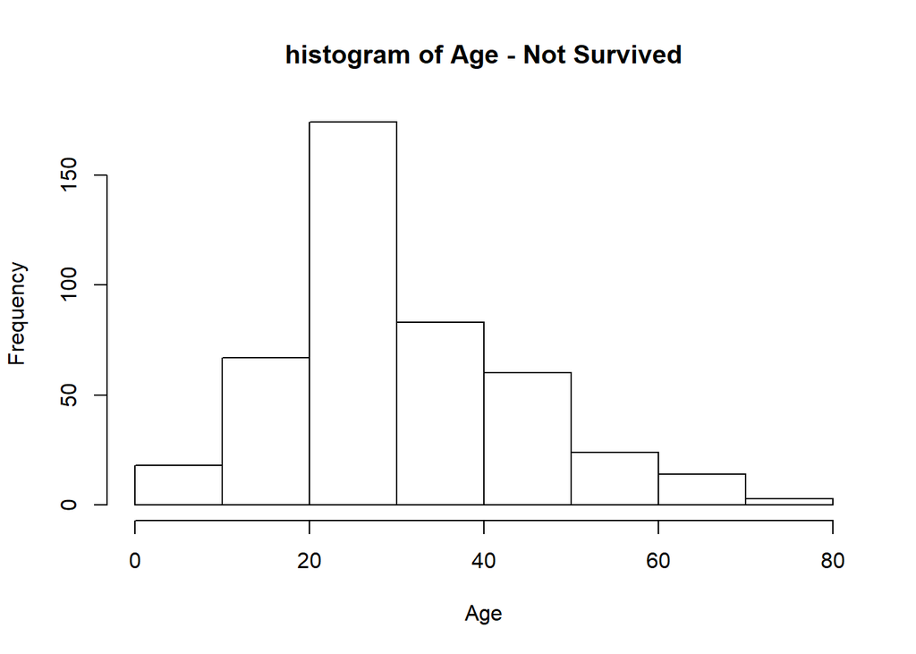

```r
hist(asu0$data1.Age,main = 'histogram of Age - Not Survived',xlab = 'Age')
```

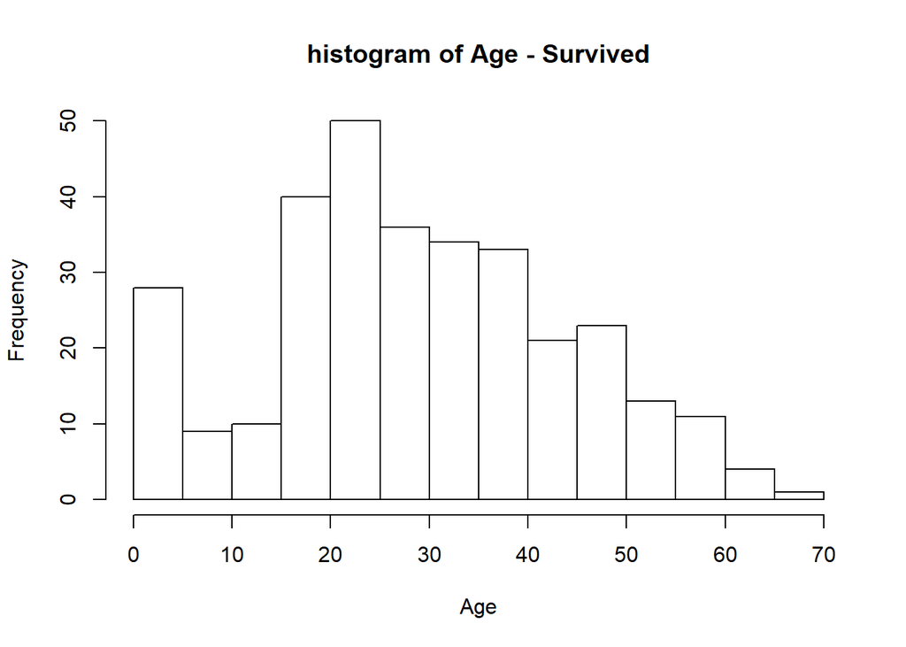

```r
hist(asu1$data1.Age,main = 'histogram of Age - Survived',xlab = 'Age')
```

###### QQNorm - Plot

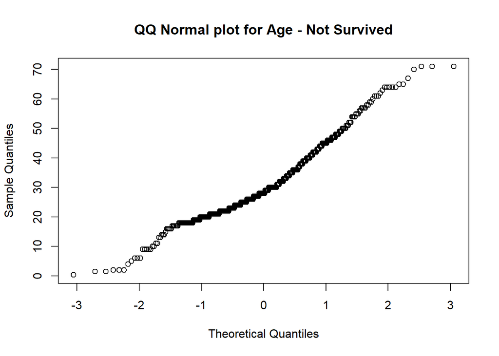

```r
qqnorm(asu0$data1.Age,main = "QQ Normal plot for Age - Not Survived")
```

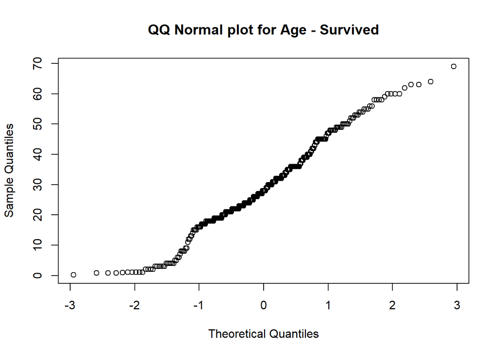

```r
qqnorm(asu1$data1.Age,main = "QQ Normal plot for Age - Survived")
```

###### Conducting Normality test for both the samples

```r
normtest(asu0$data1.Age)
```

```
##                                           Method      P.Value
## 1                    Shapiro-Wilk normality test 1.461444e-09
## 2                Anderson-Darling normality test 5.014279e-16
## 3                Cramer-von Mises normality test 7.370000e-10
## 4 Lilliefors (Kolmogorov-Smirnov) normality test 2.646866e-16
## 5                 Shapiro-Francia normality test 1.719147e-08
```

```r
normtest(asu1$data1.Age)
```

```
##                                           Method      P.Value
## 1                    Shapiro-Wilk normality test 0.0004996137
## 2                Anderson-Darling normality test 0.0017831268
## 3                Cramer-von Mises normality test 0.0068092810
## 4 Lilliefors (Kolmogorov-Smirnov) normality test 0.0322461921
## 5                 Shapiro-Francia normality test 0.0020591830
```

The P-Value of the Normality tests are less than 0.05 , strong evidence against null hypothesis ( The data follows normal distribution)

Both the data for survived and not survived people did not follow normal distribution

#### Hypothesis Testing

*Null Hypothesis*: There is a no difference in Age distribution between those who survived and those who did not.

*Alternate Hypothesis*: There is a difference in Age Distribution between those who survived and those who did not

```r
#Test
wilcox.test(asu0$data1.Age,asu1$data1.Age)
```

```
##
##  Wilcoxon rank sum test with continuity correction
##
## data:  asu0$data1.Age and asu1$data1.Age
## W = 73190, p-value = 0.1917
## alternative hypothesis: true location shift is not equal to 0
```

> Results

The P-Value of the Wilcoxon rank sum test is 0.192. The is no strong evidence against Null hypothesis.

There is a **No significant difference** between the age of the people who have survived and who have not.

#### *2.Answer the same as above after controlling for Gender.*

#### Data Analysis

```r
#Controlling for gender in the age table
gsu <- data.frame(data1$Gender,data1$Age,data1$Survived)
#Dividing Survived and Not Survived
gsu0<-subset(gsu,gsu$data1.Survived==0)
gsu1<-subset(gsu,gsu$data1.Survived==1)
```

#### Graphs and Plots

###### Barplot

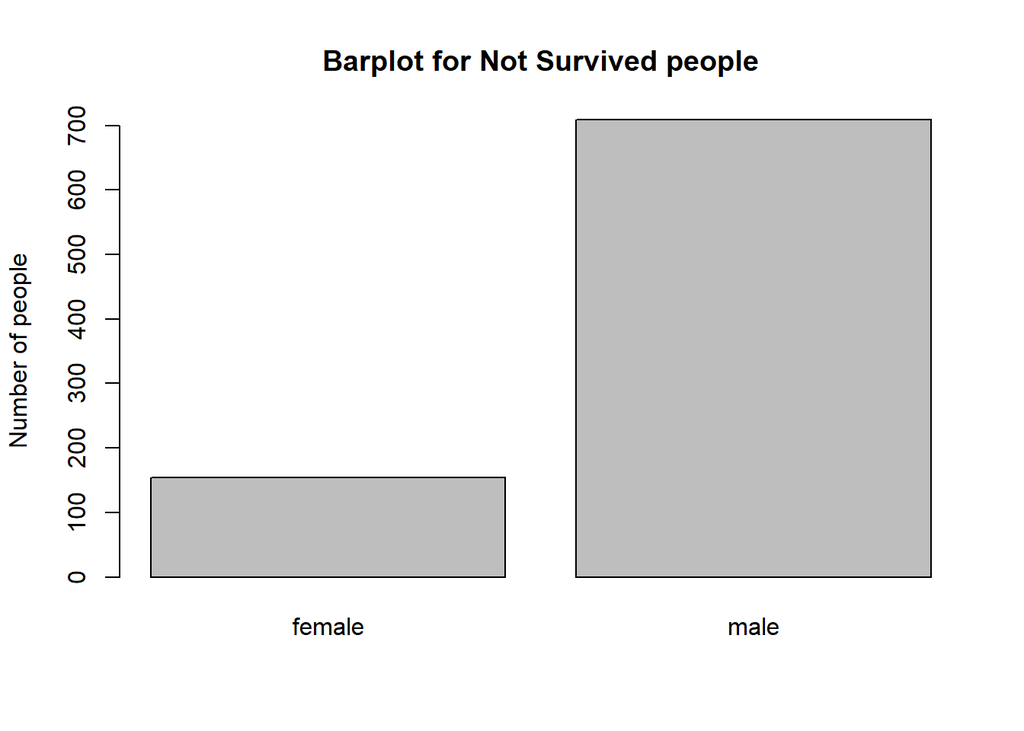

```r
barplot(table(gsu0$data1.Gender),main='Barplot for Not Survived people',ylab='Number of people')
```

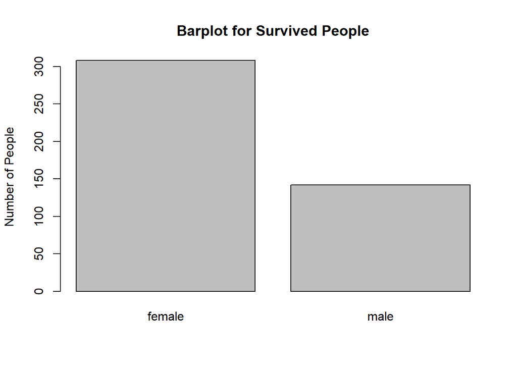

```r
barplot(table(gsu1$data1.Gender),main = 'Barplot for Survived People',ylab = 'Number of People')
```

```r
#Dividing the table for gender
msu0<-subset(gsu0,gsu0$data1.Gender=='male')
fsu0<-subset(gsu0,gsu0$data1.Gender=='female')
msu1<-subset(gsu1,gsu1$data1.Gender=='male')
fsu1<-subset(gsu1,gsu1$data1.Gender=='female')
```

###### Box Plot

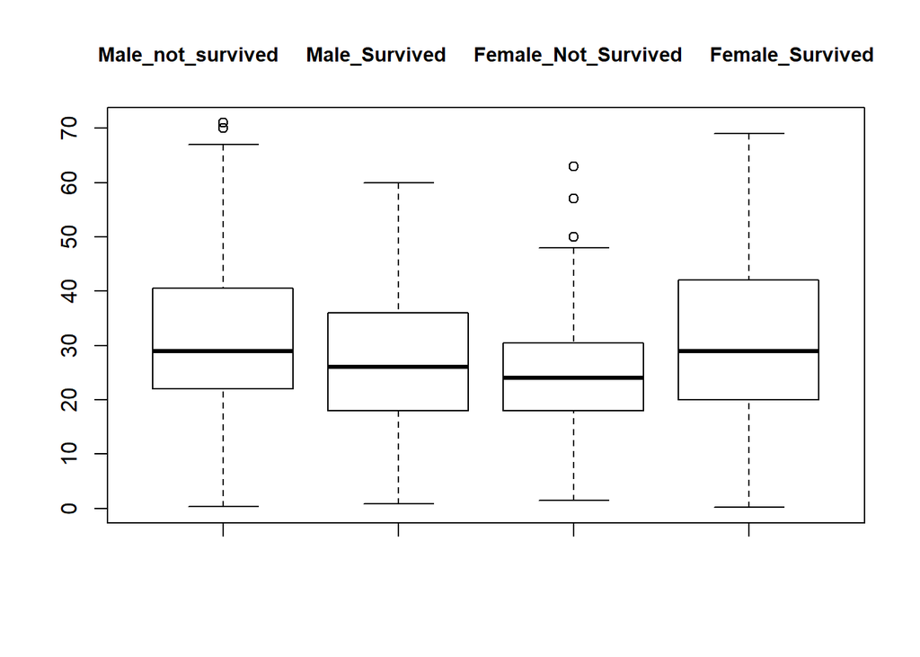

```r
boxplot(msu0$data1.Age,msu1$data1.Age,fsu0$data1.Age,fsu1$data1.Age,main='Male_not_survived     Male_Survived     Female_Not_Survived     Female_Survived',cex.main=0.9)
```

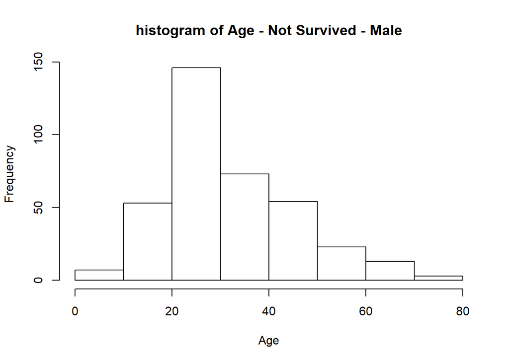

```r
hist(msu0$data1.Age,main = 'histogram of Age - Not Survived - Male',xlab = 'Age')
```

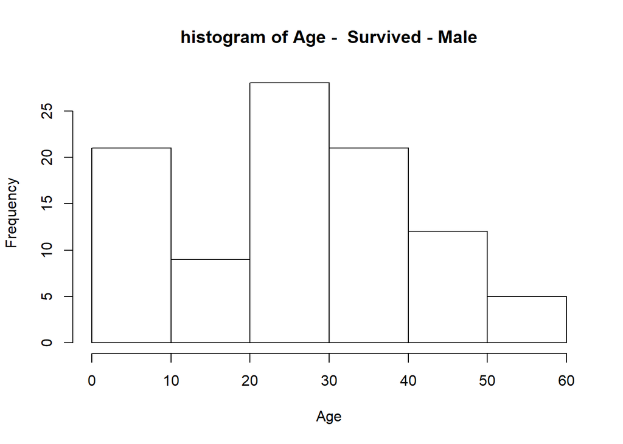

```r
hist(msu1$data1.Age,main = 'histogram of Age -  Survived - Male',xlab = 'Age')
```

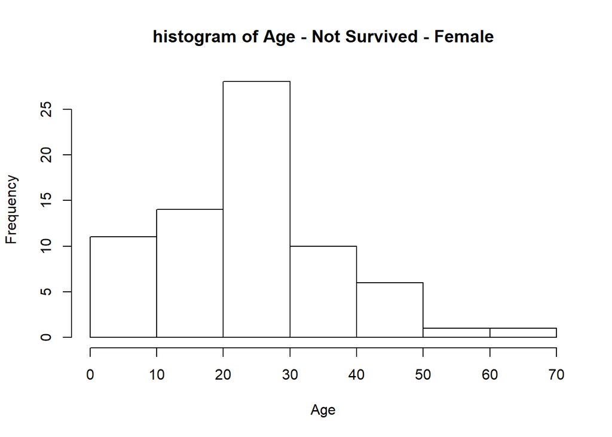

```r
hist(fsu0$data1.Age,main = 'histogram of Age - Not Survived - Female',xlab = 'Age')
```

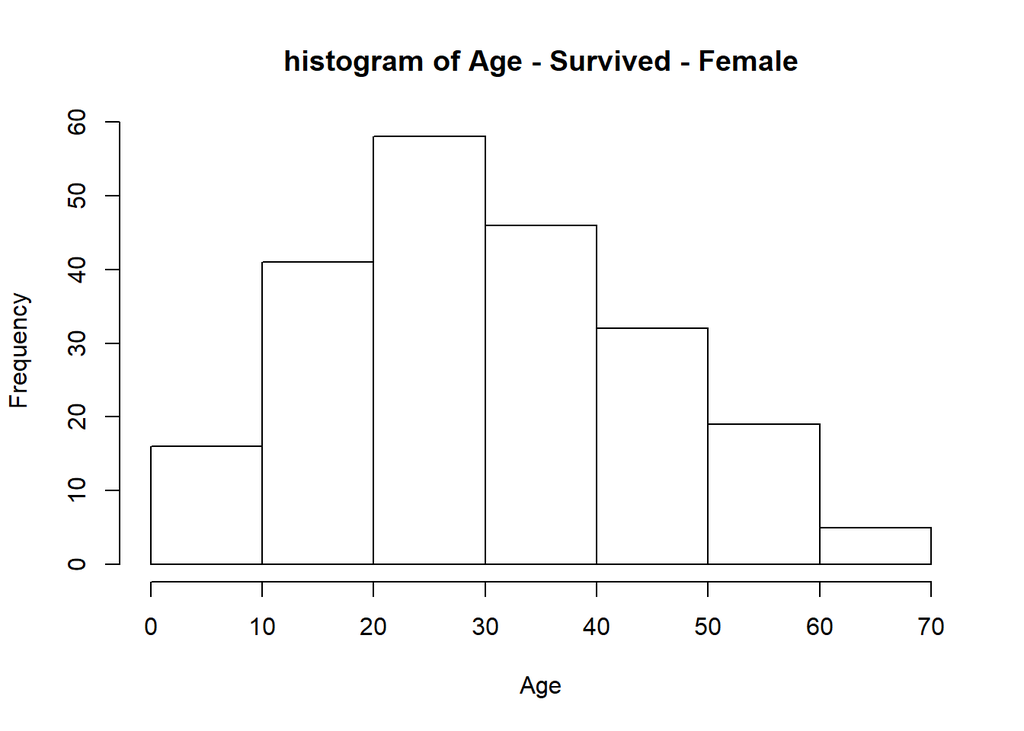

```r
hist(fsu1$data1.Age,main = 'histogram of Age - Survived - Female',xlab = 'Age')
```

###### QQNorm Plot

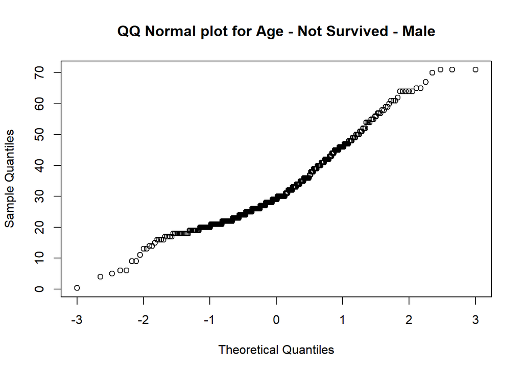

```r
qqnorm(msu0$data1.Age,main = "QQ Normal plot for Age - Not Survived - Male")
```

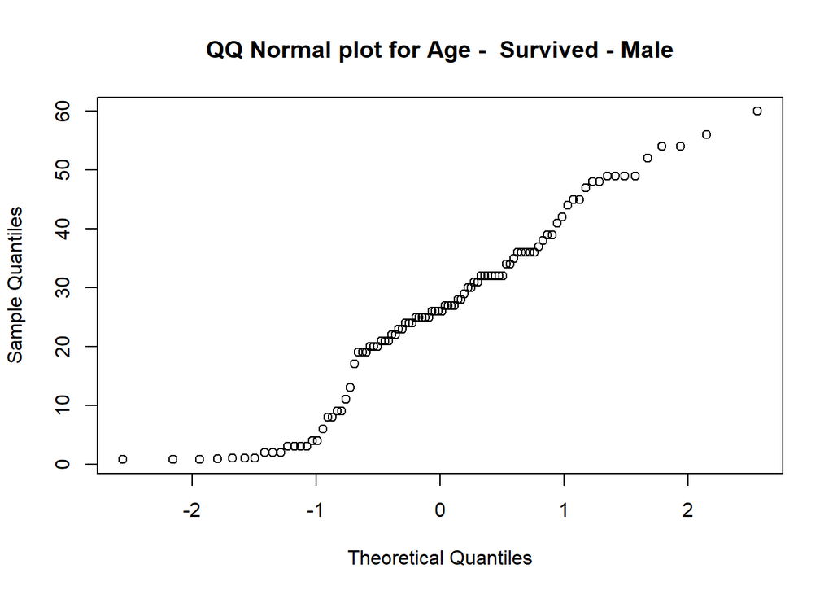

```r
qqnorm(msu1$data1.Age,main = "QQ Normal plot for Age -  Survived - Male")
```

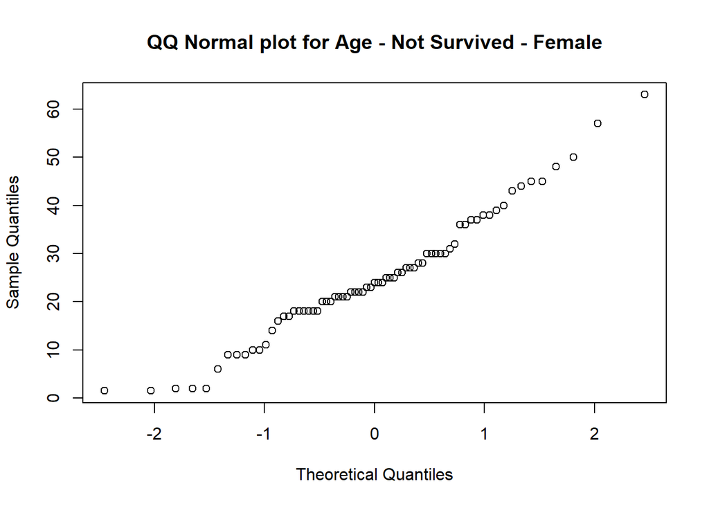

```r
qqnorm(fsu0$data1.Age,main = "QQ Normal plot for Age - Not Survived - Female")
```

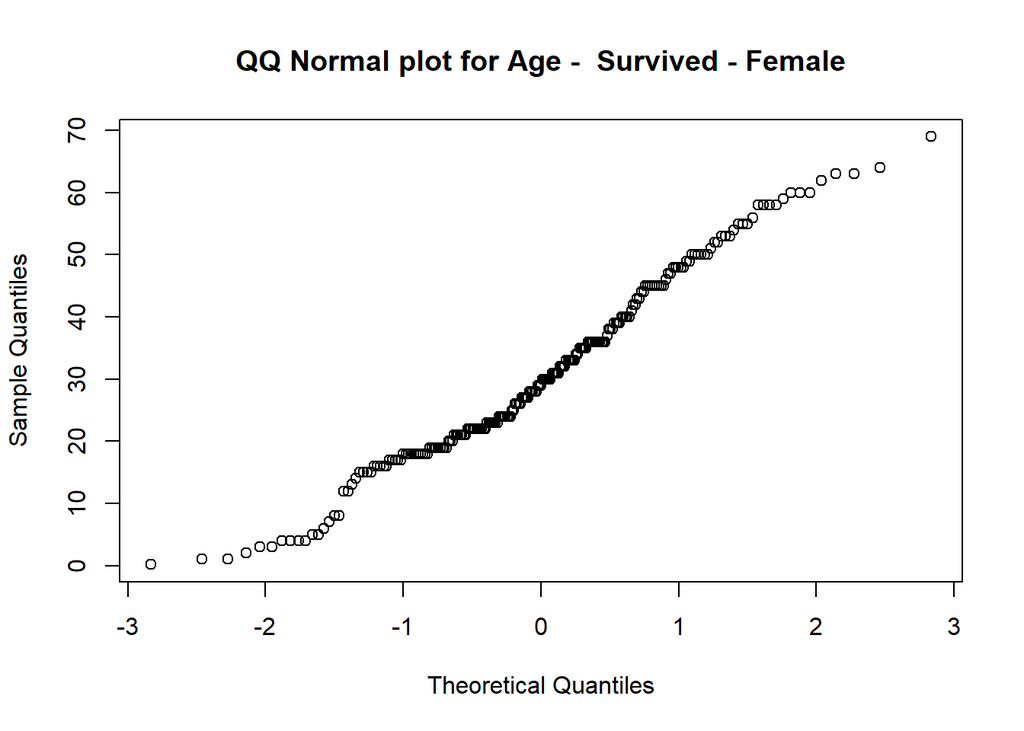

```r
qqnorm(fsu1$data1.Age,main = "QQ Normal plot for Age -  Survived - Female")
```

Normality test for both the samples

```r
normtest(msu0$data1.Age)
```

```
##                                           Method      P.Value
## 1                    Shapiro-Wilk normality test 6.368376e-10
## 2                Anderson-Darling normality test 2.227363e-16
## 3                Cramer-von Mises normality test 7.370000e-10
## 4 Lilliefors (Kolmogorov-Smirnov) normality test 6.088379e-15
## 5                 Shapiro-Francia normality test 8.325134e-09
```

```r
normtest(msu1$data1.Age)
```

```
##                                           Method     P.Value
## 1                    Shapiro-Wilk normality test 0.004201276
## 2                Anderson-Darling normality test 0.008390771
## 3                Cramer-von Mises normality test 0.045051620
## 4 Lilliefors (Kolmogorov-Smirnov) normality test 0.059854415
## 5                 Shapiro-Francia normality test 0.013508441
```

```r
normtest(fsu0$data1.Age)
```

```
##                                           Method    P.Value
## 1                    Shapiro-Wilk normality test 0.11296551
## 2                Anderson-Darling normality test 0.11530637
## 3                Cramer-von Mises normality test 0.08483381
## 4 Lilliefors (Kolmogorov-Smirnov) normality test 0.12109238
## 5                 Shapiro-Francia normality test 0.11744076
```

```r
normtest(fsu1$data1.Age)
```

```
##                                           Method      P.Value
## 1                    Shapiro-Wilk normality test 0.0026901879
## 2                Anderson-Darling normality test 0.0006357403
## 3                Cramer-von Mises normality test 0.0008234442
## 4 Lilliefors (Kolmogorov-Smirnov) normality test 0.0001661670
## 5                 Shapiro-Francia normality test 0.0077707718
```

###### Normality Test Results

Female Passengers who did not survive have a normally distributed data.

All the other categories like Male survived, Male not survived, Female survived data are not normal.

#### Hypothesis Testing - For Male

*NUll Hypothesis:* There is no signigicant difference in Age distribution between those who survived and those who did not for male.

*Alternative Hypothesis:* There is signigicant difference in Age distribution between those who survived and those who did not for male.

```r
#Tests
sigtest(msu0$data1.Age,msu1$data1.Age)
```

```
##                                              Method     P.Value
## 1                Two-sample Kolmogorov-Smirnov test 0.002006277
## 2 Wilcoxon rank sum test with continuity correction 0.003961685
```

> Results

The P-Value of both the two-sample KS test and Wilcoxon rank sum test were found to be less than 0.05.

There is a strong evidance against the Null Hypothesis.

There is signigicant difference in Age distribution between those who survived and those who did not for male.

#### Hypothesis Testing - For Female

*NUll Hypothesis:* There is no signigicant difference in Age distribution between those who survived and those who did not for Female

*Alternative Hypothesis:* There is signigicant difference in Age distribution between those who survived and those who did not for Female

```r
#Tests
sigtest(fsu0$data1.Age,fsu1$data1.Age)
```

```
##                                              Method     P.Value
## 1                Two-sample Kolmogorov-Smirnov test 0.013259850
## 2 Wilcoxon rank sum test with continuity correction 0.005118923
```

> Results

The P-Value of both the two-sample KS test and Wilcoxon rank sum test were found to be less than 0.05.

There is a strong evidance against the Null Hypothesis.

There is signigicant difference in Age distribution between those who survived and those who did not for Female.

#### *3. Remark on how Age affected the Survival Probability of a passenger on board the Titanic, based on consolidations of your findings in 1 and 2 above*

#### Data Analysis

```r
#copy to staging table
asuc1<-asu1
asuc0<-asu0
asuc0<-cut(asuc0$data1.Age,c(0,18,30,55,150))
asuc1<-cut(asuc1$data1.Age,c(0,18,30,55,150))

x<-table(asuc1)
y<-table(asuc0)

x<-data.frame(t(t(table(asuc1))))
y<-data.frame(t(t(table(asuc0))))
x<-x[-2]
y<-y[-2]
#combining tables
AgeTable<-cbind(x,y$Freq)

#renaming columns
names(AgeTable)[names(AgeTable) == "asuc1"] <- "def"
names(AgeTable)[names(AgeTable) == "Freq"] <- "Survived"
names(AgeTable)[names(AgeTable) == "y$Freq"] <- "Un-Survived"
rownames(AgeTable)<-c("Young","Young Adult","Adult","Old")
AgeTable
```

```
##                  def Survived Un-Survived
## Young         (0,18]       69          57
## Young Adult  (18,30]      104         202
## Adult        (30,55]      124         156
## Old         (55,150]       16          28
```

#### Plots and Graphs

###### Barplots

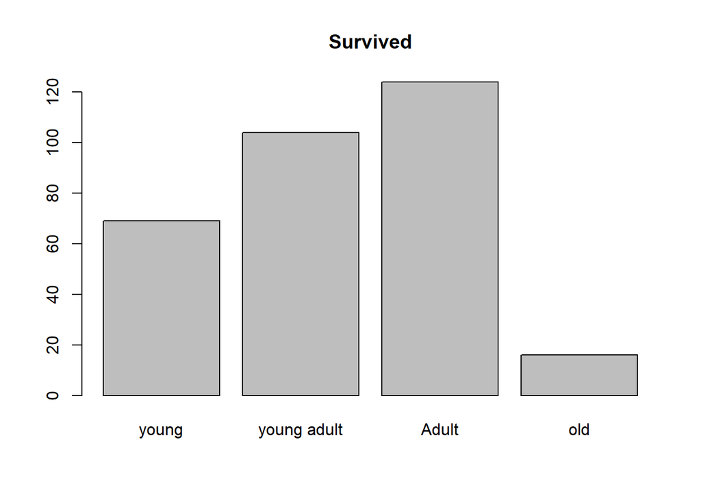

```r
#BarPlot

temp<-AgeTable$Survived
names(temp)<-c("young","young adult","Adult","old")
barplot(temp,main = 'Survived')
```

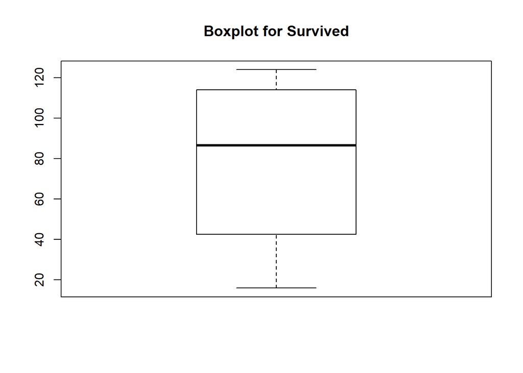

```r
boxplot(temp, main='Boxplot for Survived')
```

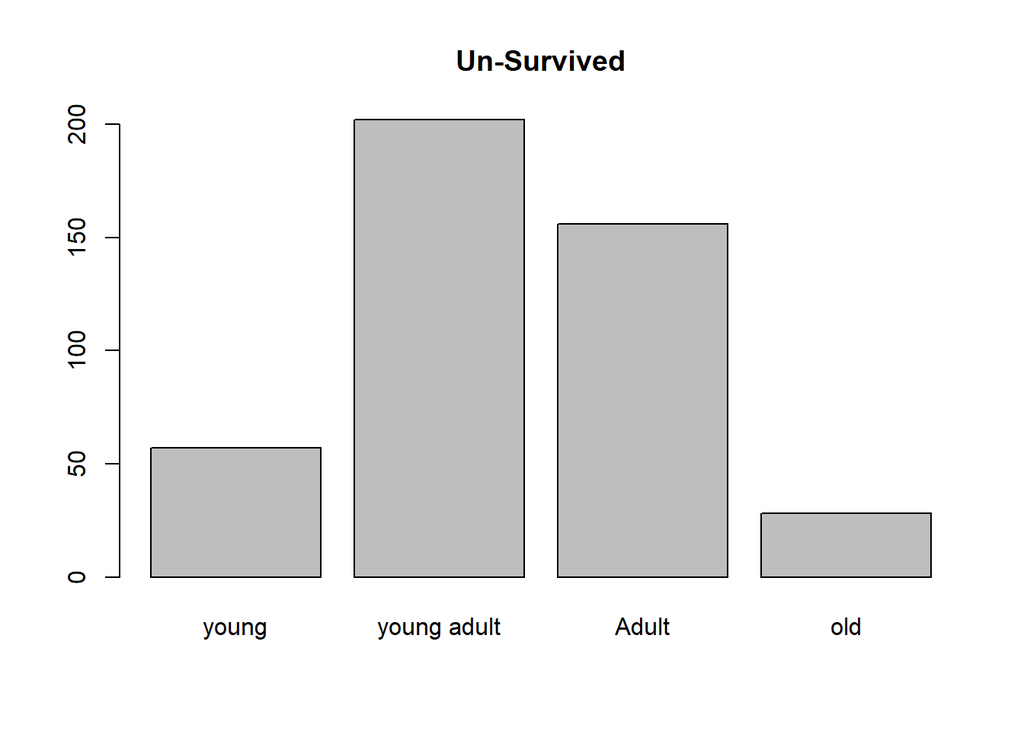

```r
temp<-AgeTable$`Un-Survived`
names(temp)<-c("young","young adult","Adult","old")
barplot(temp,main='Un-Survived')
```

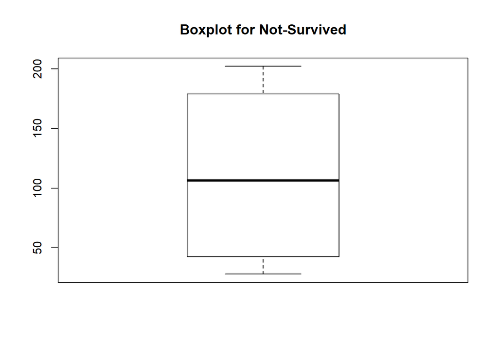

```r
boxplot(temp, main='Boxplot for Not-Survived')
```

#### Hypothesis Testing

*Null Hypothesis:* The Survival Probablity is not affected by the Age of the passanger The survival probability is homogenous across all the Age buckets

*Alternate Hypothesis:* The Survival Probability is affected by the Age of the Passanger The Survival Probability is Not Homogenous across all the Age buckets

```r
AgeTable<-AgeTable[,-1]
chisq.test(AgeTable)
```

```
##
##  Pearson's Chi-squared test
##
## data:  AgeTable
## X-squared = 17.625, df = 3, p-value = 0.0005255
```

> Results

There is a strong evidence against the null hypothesis

The Survival Probability is affected by the Age Distribution.

#### *4. Is there a significant difference in Survival Probability between the two genders?*

#### Data Analysis

##### Gender based Survival Table

```r
#copy to staging table
gen<-data.frame(data1$Gender,data1$Survived)
gen0<-subset(gen,gen$data1.Survived==0)
gen1<-subset(gen,gen$data1.Survived==1)

gen0<-data.frame(t(t(table(gen0$data1.Gender))))

gen1<-data.frame(t(t(table(gen1$data1.Gender))))

gen0<-gen0[-2]
gen0<-gen0[-1]
gen1<-gen1[-2]
gen1<-gen1[-1]
#Combining Table
GenderTable<-cbind(gen0,gen1$Freq)
rownames(GenderTable)<-c("Female","Male")
colnames(GenderTable)<-c("Survived","Not-Survived")

GenderTable
```

[output not shown]

[figure not shown]

```r
temp<-GenderTable$Survived
names(temp)<-c("Female","Male")
barplot(temp,main = "Survived")
```

[figure not shown]

```r
temp<-GenderTable$`Not-Survived`
names(temp)<-c("Female","Male")
barplot(temp,main = "Not-Survived")
```

#### Hypothesis Testing

*Null Hypothesis:* There is no difference in the survival probability between the two genders

*Alternative Hypothesis:* There is a difference in the survival probability between the two genders

```r
nptest(GenderTable)
```

```
##                                                         Method
## 1 Pearson's Chi-squared test with Yates' continuity correction
## 2                           Fisher's Exact Test for Count Data
##        P.Value
## 1 1.040403e-73
## 2 4.826448e-74
```

> Results

Both the Chi-Sq test and Fisher test are giving P-Value less than 0.05.

There is a strong evidence against Null Hypothesis

The Survival Rate is dependent on the Gender based on chi square test for independence and Fisher’s Exact

#### *5. Is there a significant difference in Survival Probability between the three passenger classes?*

#### Data Analysis

##### Passanger Class Table

```r
temp<-subset(data1,data1$Survived==0)
temp<-subset(temp,temp$PClass=='1st')
class1n<-data.frame(temp$PClass,temp$Survived)

temp<-subset(data1,data1$Survived==1)
temp<-subset(temp,temp$PClass=='1st')
class1s<-data.frame(temp$PClass,temp$Survived)

temp<-subset(data1,data1$Survived==0)
temp<-subset(temp,temp$PClass=='2nd')
class2n<-data.frame(temp$PClass,temp$Survived)

temp<-subset(data1,data1$Survived==1)
temp<-subset(temp,temp$PClass=='2nd')
class2s<-data.frame(temp$PClass,temp$Survived)

temp<-subset(data1,data1$Survived==0)
temp<-subset(temp,temp$PClass=='3rd')
class3n<-data.frame(temp$PClass,temp$Survived)

temp<-subset(data1,data1$Survived==1)
temp<-subset(temp,temp$PClass=='3rd')
class3s<-data.frame(temp$PClass,temp$Survived)

class1s<-table(class1s)
class1n<-table(class1n)
class2s<-table(class2s)
class2n<-table(class2n)
class3n<-table(class3n)
class3s<-table(class3s)

ClassTable<-matrix(c(class1s[-2:-3],class1n[-2:-3],class2s[2],class2n[2],class3s[3],class3n[3]),ncol=2,byrow=TRUE)
rownames(ClassTable)<-c("Class-1","Class-2","Class-3")
colnames(ClassTable)<-c("Survived","Un-Survived")
ClassTable
```

```
##         Survived Un-Survived
## Class-1      193         129
## Class-2      119         161
## Class-3      138         573
```

#### Hypothesis Testing

*Null Hypothesis:* The Survival probability is same across all the passanger class

*Alternate Hypothesis:* The Survival probability is not same across all the passanger class

```r
nptest(ClassTable)
```

```
##                               Method      P.Value
## 1         Pearson's Chi-squared test 3.852316e-38
## 2 Fisher's Exact Test for Count Data 2.791493e-38
```

> Results The P-Value given by both Chi-Sq test and Fisher’s Exact test are less than 0.05.

There is a strong evidence against Null hypothesis.

The survival probability is not distributed evenly across the P-Class.

#### *6. Is there a significant difference in Survival Probability between the two genders even after taking the effect of Passenger Class into Account?*

#### Data Analysis

```r
#The Gender Table Generator for Different classes
gtrans<-function(x)
{
gen<-data.frame(q6$Gender,q6$Survived)
gen0<-subset(gen,gen$q6.Survived==0)
gen1<-subset(gen,gen$q6.Survived==1)

gen0<-data.frame(t(t(table(gen0$q6.Gender))))

gen1<-data.frame(t(t(table(gen1$q6.Gender))))

gen0<-gen0[-2]
gen0<-gen0[-1]
gen1<-gen1[-2]
gen1<-gen1[-1]
#Combining Table
GenderTable<-cbind(gen0,gen1$Freq)
rownames(GenderTable)<-c("Female","Male")
colnames(GenderTable)<-c("Survived","Not-Survived")

return(GenderTable)
}
```

#### Table for Class 1

```r
q6<-subset(data1,data1$PClass=='1st')
temp<-gtrans(q6)
temp
```

```
##        Survived Not-Survived
## Female        9          134
## Male        120           59
```

#### Hypothesis Testing for Class-1 Passengers

*Null Hypothesis:* There is no difference between the survival proportion between the male and female passanger of class 1

*Alternate Hypothesis:* There is a significant difference between the survival proportion between the male and female passanger of class 1

```r
nptest(temp)
```

```
##                                                         Method
## 1 Pearson's Chi-squared test with Yates' continuity correction
## 2                           Fisher's Exact Test for Count Data
##        P.Value
## 1 7.576739e-28
## 2 1.086515e-31
```

> Results

The P-Value of both the Chi-Sq test and Fisher Exact Test is less than 0.05

There is a strong evidence against Null Hypothesis

Theere is a significant difference between the Survival Probablity of Male and Female of the class-1 Passangers.

#### Table for Class 2

```r
q6<-subset(data1,data1$PClass=='2nd')
temp<-gtrans(q6)
temp
```

```
##        Survived Not-Survived
## Female       13           94
## Male        148           25
```

#### Hypothesis Testing for Class-2 Passengers

*Null Hypothesis:* There is no difference between the survival proportion between the male and female passanger of class 2

*Alternate Hypothesis:* There is a significant difference between the survival proportion between the male and female passanger of class 2

```r
nptest(temp)
```

```
##                                                         Method
## 1 Pearson's Chi-squared test with Yates' continuity correction
## 2                           Fisher's Exact Test for Count Data
##        P.Value
## 1 6.633397e-33
## 2 5.079791e-36
```

> Results

The P-Value of both the Chi-Sq test and Fisher Exact Test is less than 0.05

There is a strong evidence against Null Hypothesis

Theere is a significant difference between the Survival Probablity of Male and Female of the class-2 Passangers.

#### Table for Class-3

```r
q6<-subset(data1,data1$PClass=='3rd')
temp<-gtrans(q6)
temp
```

```
##        Survived Not-Survived
## Female      132           80
## Male        441           58
```

#### Hypothesis Testing for Class-3 Passengers

*Null Hypothesis:* There is no difference between the survival proportion between the male and female passanger of class 3

*Alternate Hypothesis:* There is a significant difference between the survival proportion between the male and female passanger of class 3

```r
chisq.test(temp)
```

```
##
##  Pearson's Chi-squared test with Yates' continuity correction
##
## data:  temp
## X-squared = 63.201, df = 1, p-value = 1.867e-15
```

> Results

There is a strong evidence against Null Hypothesis

There is a significant difference between the Survival Probablity of Male and Female of the class-3 Passangers.